# BST260 Final Project

Takahisa Ogawa Kazuma Oyama Keitaro Mahara Keiko Kunitoki

12/12/2019

## Impact of distance to hospital on amputation rate in trauma patients

## Introduction

• The number of amputation has recently been increasing.

• Amputation largely affect the patients’ quality of life.

• The success for limb salvage depends on standby time before surgery.

• Logistics such as distance from injury site to a hospital has an important role on the time before surgery

## Objectives

• To investigate the association between the distance from injury site to a hospitalization and amputation in trauma patients.

## Distance

• The U.S. Geological Survey developed the Geographic Names Information System (GNIS) for the U.S. Board on Geographic Names.

• Distance is calculated by ArcGIS pro with Point Distance function.

• Used minimum distance(Meter)

## Data wrangling

```r
library(tidyverse)
library(readr)


data <- read_delim("injurydata.csv",";", escape_double = FALSE, trim_ws = TRUE)
#add_state population
f <-read_csv("state_pop.csv",col_names = F)
f <- rename(f,STATE=X1)
f <- rename(f,POP=X2)
datax <- data %>% left_join(f, by="STATE")


#filter hospitarisation(0/1)
dataa <- datax %>% filter(HOSPITALIZED<2)
datas <- dataa %>% filter(HOSPITALIZED>-1)
#filter amputation(0/1)
datad <- datas %>% filter(AMPUTATION<2)
dataf <- datad %>% filter(AMPUTATION>-1)
#filter by hospital id
dataq <- dataf %>% filter(NEAR_FID>0)

#distance less than 10^5 meter
data <- dataq %>% filter(NEAR_DIST<10^5)

#add_multiple injury
Left<-function(x,chr){
  return(substr(x,1,chr))}

data<-mutate(data, leftMul = Left(PARTOFBODYTITLE,3))
data<-mutate(data, MultiInj = ifelse(data$leftMul=="Mul", "1", "0"))
data
```

```
## # A tibble: 44,660 x 39
##    XCoord YCoord OBJECTID     ID    UPA EVENTDATE           EMPLOYER
##     <dbl>  <dbl>    <dbl>  <dbl>  <dbl> <dttm>              <chr>
##  1  -74.5   41.5        1 2.02e9 931176 2015-01-01 00:00:00 FCI Oti~
##  2  -89.8   43.6        2 2.02e9 930267 2015-01-01 00:00:00 Kalahar~
##  3  -80.1   40.5        3 2.02e9 929823 2015-01-01 00:00:00 Schneid~
##  4  -83.6   32.8        4 2.02e9 929711 2015-01-01 00:00:00 PEPSI B~
##  5  -89.0   42.7        5 2.02e9 929642 2015-01-01 00:00:00 North A~
##  6  -81.9   26.7        6 2.02e9 929709 2015-01-01 00:00:00 The Hom~
##  7  -82.4   28.0        7 2.02e9 932133 2015-01-01 00:00:00 Gopher ~
##  8 -105.    40.5        8 2.02e9 930028 2015-01-02 00:00:00 Foster ~
##  9  -99.4   36.4        9 2.02e9 930006 2015-01-02 00:00:00 Trinida~
## 10  -81.5   28.6       10 2.02e9 933583 2015-01-02 00:00:00 The Kry~
## # ... with 44,650 more rows, and 32 more variables: ADDRESS1 <chr>,
## #   ADDRESS2 <chr>, CITY <chr>, STATE <chr>, ZIP <chr>, LATITUDE <chr>,
## #   LONGITUDE <chr>, PRIMARYNAICS <dbl>, HOSPITALIZED <dbl>,
## #   AMPUTATION <dbl>, INSPECTION <chr>, FINALNARRATIVE <chr>,
## #   NATURE <chr>, NATURETITLE <chr>, PARTOFBODY <chr>,
## #   PARTOFBODYTITLE <chr>, EVENT <chr>, EVENTTITLE <chr>, SOURCE <chr>,
## #   SOURCETITLE <chr>, SECONDARYSOURCE <chr>, SECONDARYSOURCETITLE <chr>,
## #   DATE <chr>, DATE_X <chr>, DATE_Y <chr>, NEAR_FID <chr>,
## #   NEAR_DIST <dbl>, NEAR_X <dbl>, NEAR_Y <dbl>, POP <dbl>, leftMul <chr>,
## #   MultiInj <chr>
```

## Relationship betweem population and the number of injury according to states

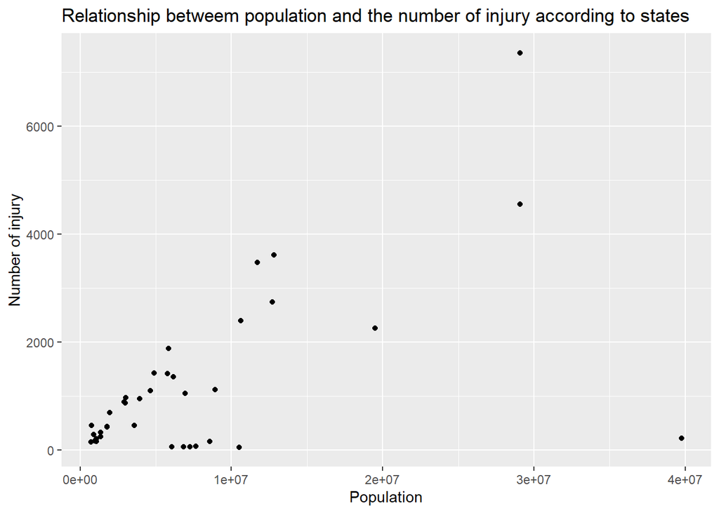

```r
# group by state
injury_state <- data %>% group_by(STATE) %>% summarise(number = n())

# add population data
injury_state_pop <- transform(injury_state, population = c(4898246,735720,7275070,3026412,39747267,5770545,3567871,975033,711571,29087070,10627767,162742,1416589,1790182,12700381,6718616,3167997,2910931,4484047,4652581,1342097,6062917,6939373,10020472,5655925,2987895,6147861,1074532,1940919,3087025,1363852,8922547,2096034,19491339,10497741,760900,55144,11718568,3948950,4245901,12813969,3113659,1056738,5147111,892631,6833793,29087070,3221610,627180,106405,8571946,7666343,1791951,5832661,572381)) %>% filter(number > 50)
# visualize
ggplot(data = injury_state_pop, aes(x = population, y = number, label = STATE)) +
  labs(title = "Relationship betweem population and the number of injury according to states ", x = "Population", y = "Number of injury") + geom_point()
```

This plot shows that the more populous states have more trauma.

## Hospitalization Rate in All Injuries

```r
# check a frequency of hospitalization
pie_chart_hosp1 <- data %>% select(HOSPITALIZED)
table(pie_chart_hosp1)
```

```
## pie_chart_hosp1
##     0     1
##  8810 35850
```

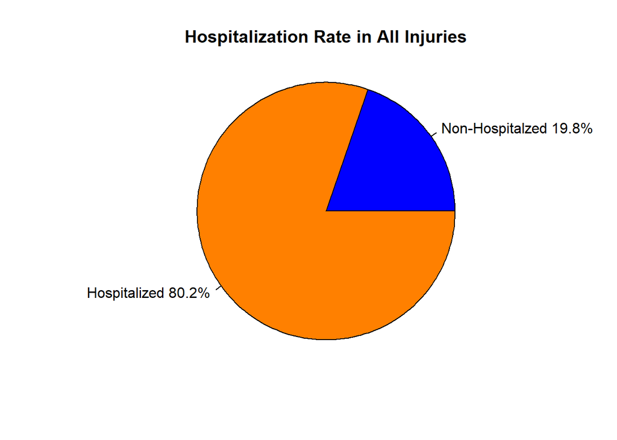

```r
# make a pie chart
pie_chart_hosp2 <- c(table(pie_chart_hosp1)[1],table(pie_chart_hosp1)[2])
pie(pie_chart_hosp2, radius=1, labels=c("Non-Hospitalzed 19.8%","Hospitalized 80.2%"), col=c("#0000FF","#FF8000"), main="Hospitalization Rate in All Injuries")
```

The pie chart shows that a hospitalization rate is nearly 80%.

## Amputation Rate in All Injuries

```r
# check a frequency of amputation
pie_chart_amp1 <- data %>% select(AMPUTATION)
table(pie_chart_amp1)
```

```
## pie_chart_amp1
##     0     1
## 32749 11911
```

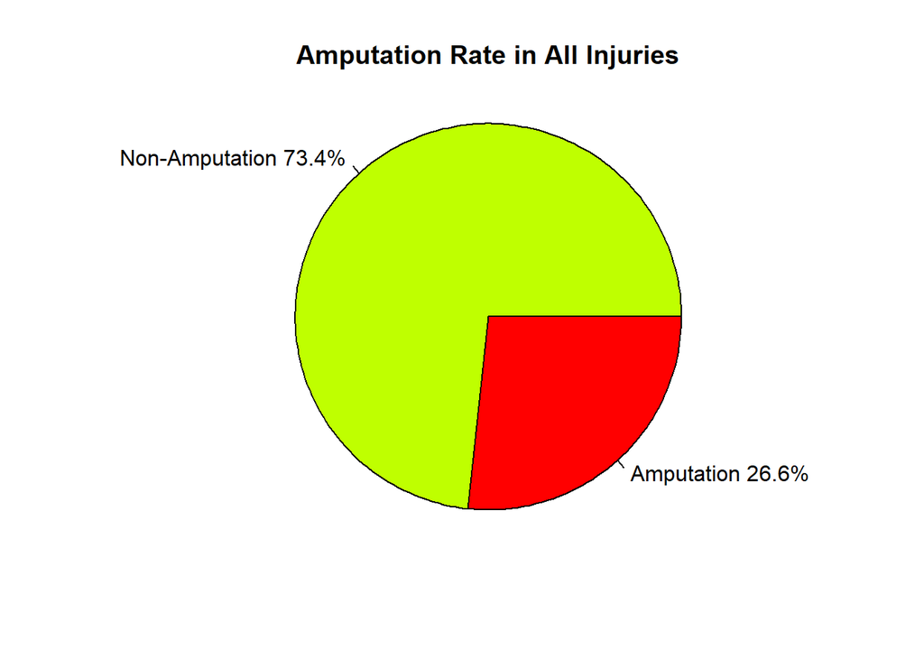

```r
# make a pie chart
pie_chart_amp2 <- c(table(pie_chart_amp1)[1],table(pie_chart_amp1)[2])
pie(table(pie_chart_amp1), radius=1, labels=c("Non-Amputation 73.4%","Amputation 26.6%"), col=c("#BFFF00","#FF0000"), main="Amputation Rate in All Injuries")
```

The pie chart shows that an amputation rate is nearly a quarter in red. These results suggest that the subject of our study was relatively severe patients.

## Relationship betweem Hospitalization and Amputation Rates according to States

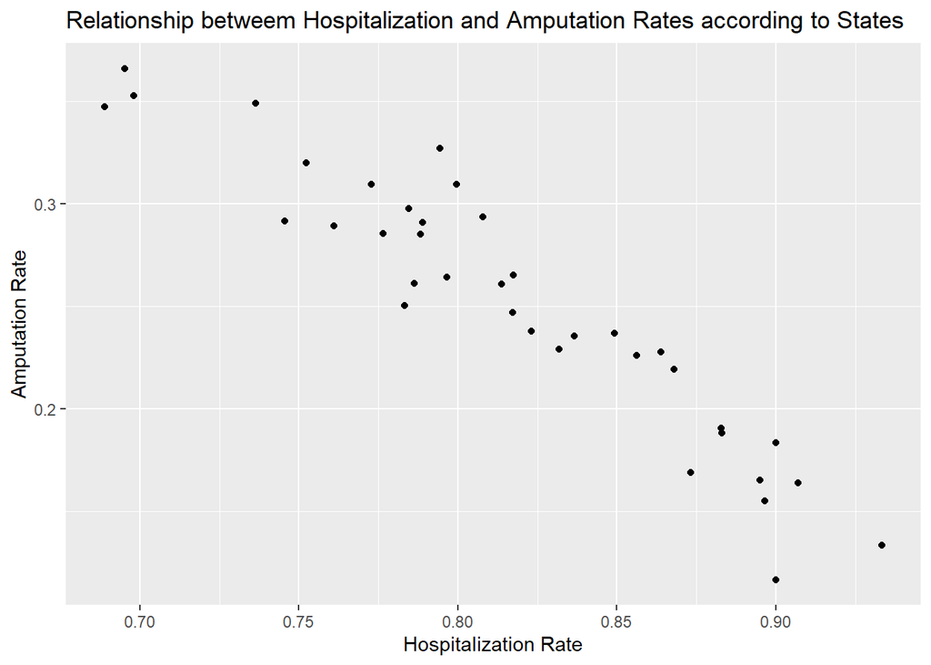

```r
# group by state
data_ah_rate <- data %>% group_by(STATE) %>%
  summarise(amputation_rate = mean(AMPUTATION), hospitalazation_rate = mean(HOSPITALIZED),
            number = n()) %>%
  filter(number > 50)
# visualize
ggplot(data = data_ah_rate, aes(x = hospitalazation_rate, y = amputation_rate, label = STATE)) +
  labs(title = "Relationship betweem Hospitalization and Amputation Rates according to States ", x = "Hospitalization Rate", y = "Amputation Rate") + geom_point()
```

The plot shows hospitalization rates by state and amputation rates by state are negatively correlated.

## longitudinal analysis

```r
#load library
library(lubridate)
```

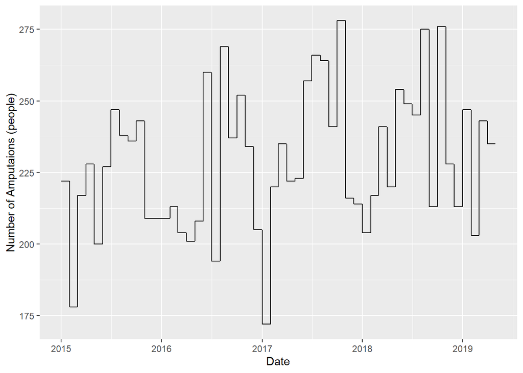

```r
data2 <- data %>% mutate(month = month(EVENTDATE), year = year(EVENTDATE))

#extract year and month format
timeseries <- data2%>% group_by(year,month) %>%
  summarise(amputation =sum(AMPUTATION)) %>% inner_join(data2, by=c('year'='year','month'='month'))

#Aggregate data into each month level
timeseries <- data2 %>% group_by(year, month) %>%
  mutate(amputation =sum(AMPUTATION))

#line graph
timeseries %>% ggplot()+aes(EVENTDATE,amputation) +geom_line()+
  xlab('Date')+ylab('Number of Amputaions (people)')
```

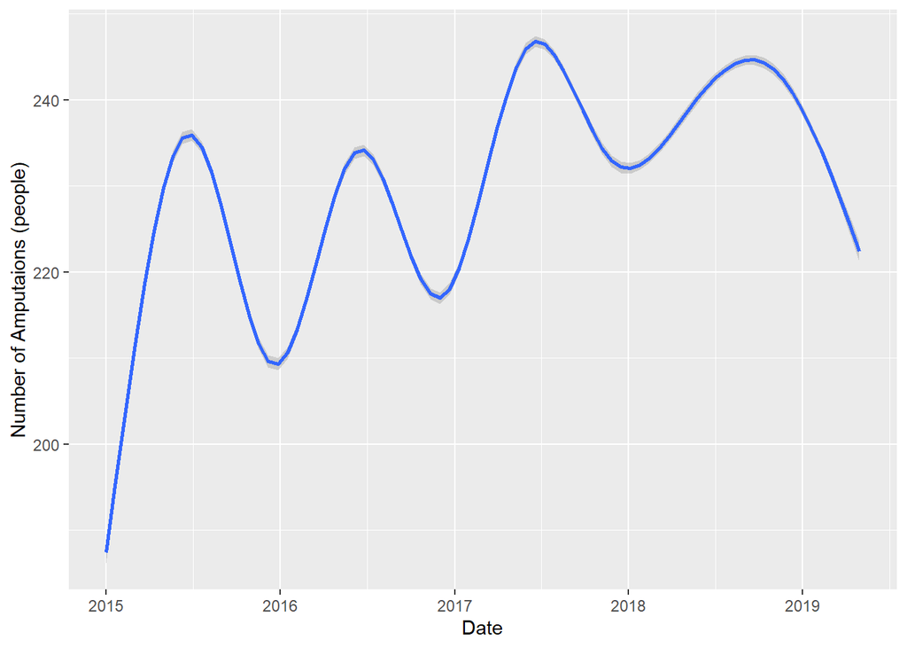

```r
#smooth line graph
timeseries %>% ggplot()+aes(EVENTDATE,amputation) +geom_smooth()+
  xlab('Date')+ylab('Number of Amputaions (people)')
```

According to longitudinal data, there was a tendensy that in summer, the number of amputation increased, where as in the winter it decreased. Over all, the number of amputation looks increasing.

## Natural Language Processing Infrastructure (NLP)

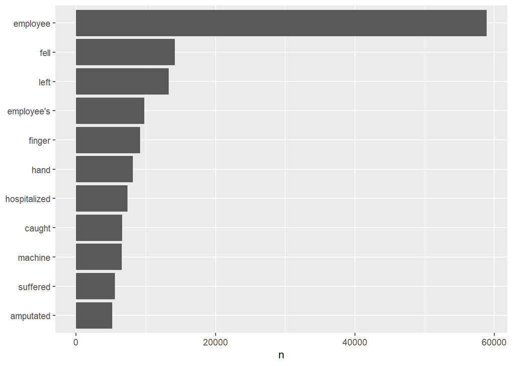

```r
library(tidytext)
library(tidyverse)
library(wordcloud2)

#NLP Extract text data and remove functional words such as articles or prepositions
text <- data %>%  unnest_tokens(word, FINALNARRATIVE)
data(stop_words)
text <- text %>% anti_join(stop_words)
text <-transform(text,Freq=0)

#Bar chart
text %>%
  count(word, sort = TRUE) %>%
  filter(n > 5000) %>%
  mutate(word = reorder(word, n)) %>%
  ggplot(aes(word, n)) +
  geom_col() +
  xlab(NULL) +
  coord_flip()
```

The bar chart shows the top eleven frequent words used in electoric health records. Many people could injured their left side hand or fingers. Machine could be the possible reason of amputation.

```r
#Word Cloud
library(wordcloud2)
wctext <- text %>% group_by(word) %>% mutate(Freq = n())

wctext%>% select(word,Freq)%>%
  distinct(word, .keep_all = TRUE)%>%
  arrange(desc(Freq)) %>%
  wordcloud2()
```

[interactive chart not shown]

Wordcloud shows a fancy visualization that reflects the result of the barchart above.

## Distance from hospital according to states

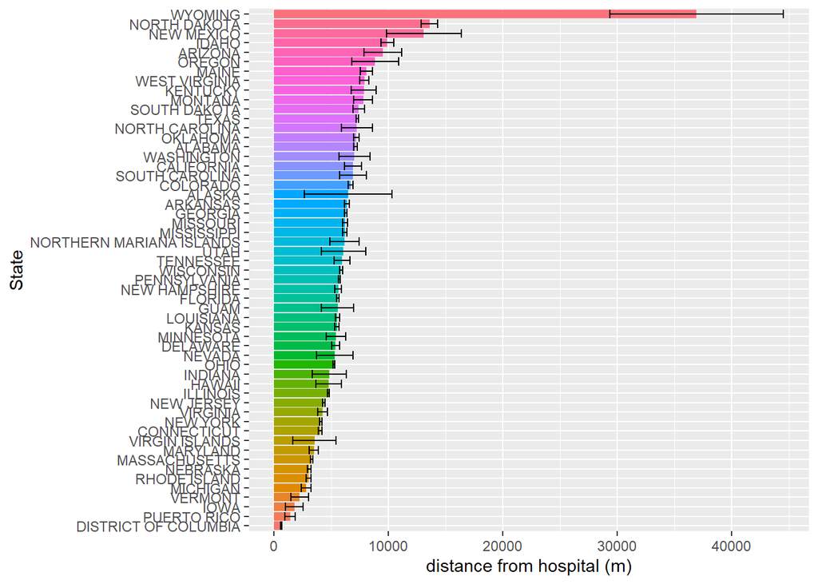

Wyoming, North Dakota, and New Mexico were the three states with the longest distance from the injury site to the hospital.

## Amputation rate and distance according to states on us map

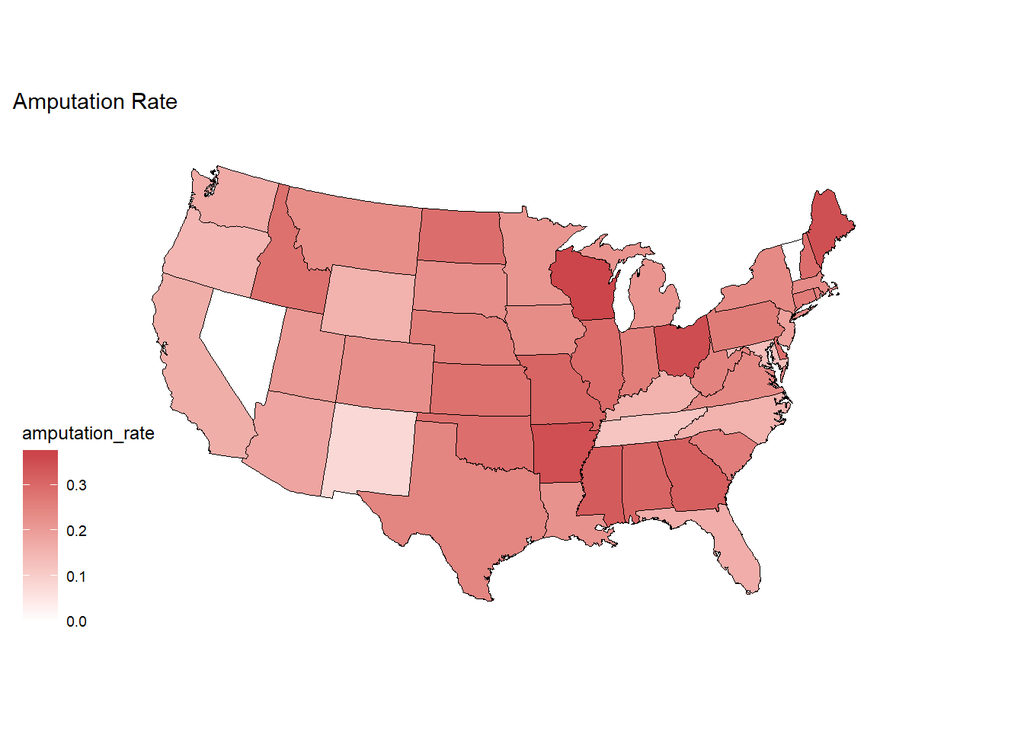

```r
# group by states and summarise
data_amputation_rate <- data %>% group_by(STATE) %>%
  summarise(mean = mean(NEAR_DIST), sd =sd(NEAR_DIST), se = sd(NEAR_DIST)/sqrt(n()),amputation_rate = mean(AMPUTATION), amputation =sum(AMPUTATION))

# manipulate data for the map
# use us map data and lefh_join by region
data_amputation_rate_1 <- data_amputation_rate %>%
  mutate(region = str_to_lower(STATE))
library(maps)
states_map <- map_data("state")
amputation_map <- left_join(states_map, data_amputation_rate_1, by = "region")

# Create the map
library(ggthemes)
amputation_map %>%
ggplot(mapping = aes(long, lat, group = group,fill = amputation_rate))+
  geom_polygon(color = "black", size = 0.1) +
  coord_map(projection = "albers", lat0 = 39, lat1 = 45) +
  labs(title = "Amputation Rate") +
  theme_map() +
  scale_fill_gradient(low = "white", high = "#CB454A")
```

It seems that the amputation rate is slightly high from the central part to the middle east part of the US.

## Amputation rate and distance according to states

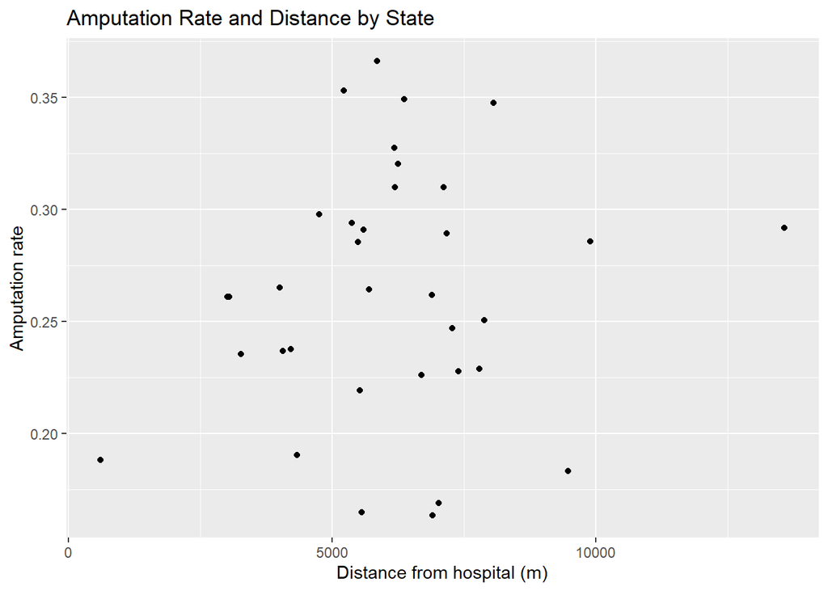

```r
# visualize on scatterplot
data_amputation_rate <- data_amputation_rate %>% filter(amputation >= 10)
  data_amputation_rate  %>%
  ggplot(aes(x = mean, y = amputation_rate, label = STATE)) +
  geom_point()+
  xlab("Distance from hospital (m)")+
  ylab("Amputation rate")+
  ggtitle("Amputation Rate and Distance by State")
```

```r
# add state abbreviation and change size according to the number of amputation
library(openintro)
```

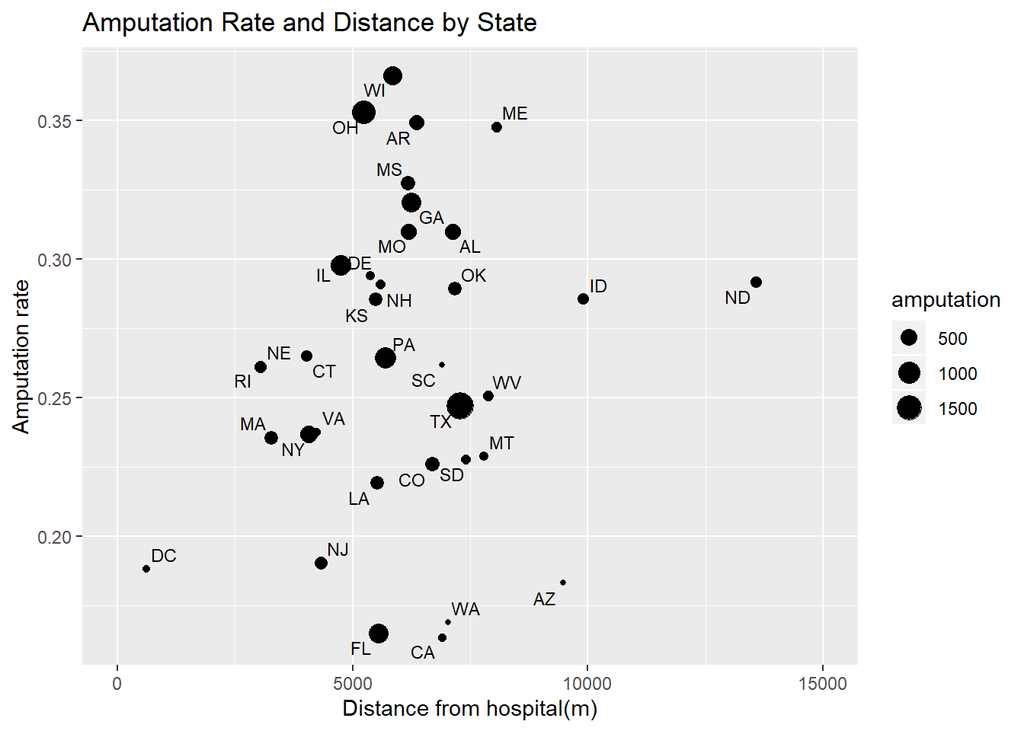

```r
library(ggrepel)

data_amputation_rate %>%
  mutate(abb = state2abbr(STATE)) %>%
  ggplot(aes(x = mean, y = amputation_rate, label = abb, size = amputation)) +
  geom_point()+
  geom_text_repel(size =3) +
  xlab("Distance from hospital(m)")+
  ylab("Amputation rate") +
  xlim(0,15000) +
  ggtitle("Amputation Rate and Distance by State")
```

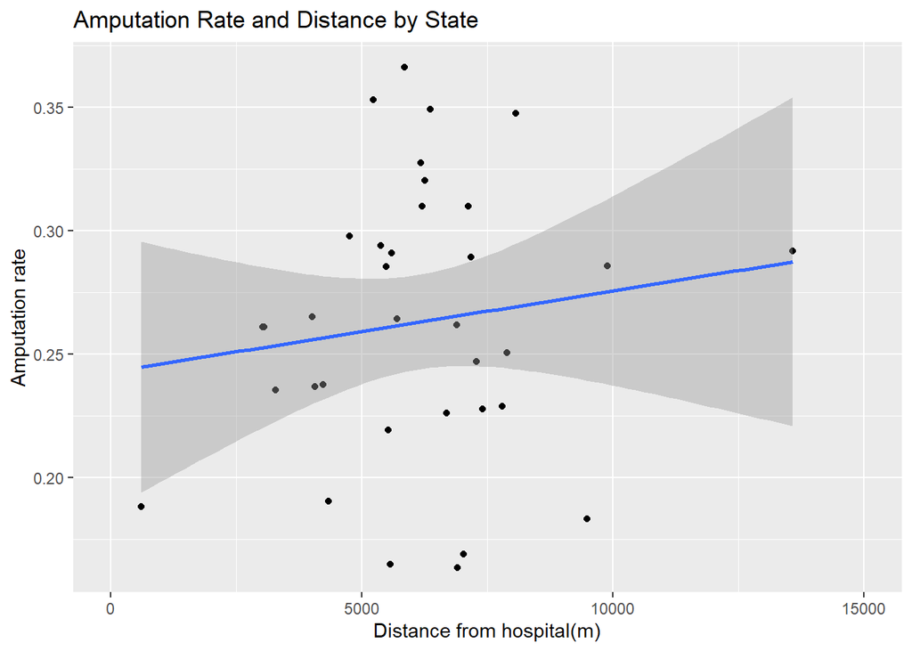

```r
# add regression line
data_amputation_rate %>%
  ggplot(aes(x = mean, y = amputation_rate, label = STATE)) +
  geom_point()+
  geom_smooth(method="lm") +
  xlab("Distance from hospital(m)")+
  ylab("Amputation rate") +
  xlim(0,15000) +
 ggtitle("Amputation Rate and Distance by State")
```

```r
# check correlation
tidy(cor.test(data_amputation_rate$mean, data_amputation_rate$amputation_rate))
```

```
## # A tibble: 1 x 8
##   estimate statistic p.value parameter conf.low conf.high method
##      <dbl>     <dbl>   <dbl>     <int>    <dbl>     <dbl> <chr>
## 1    0.135     0.784   0.439        33   -0.207     0.448 Pears~
## # ... with 1 more variable: alternative <chr>
```

In the analysis by state, the distance from the injury site to the hospital and amputation had no apparent association.

## Hospital location on injury map

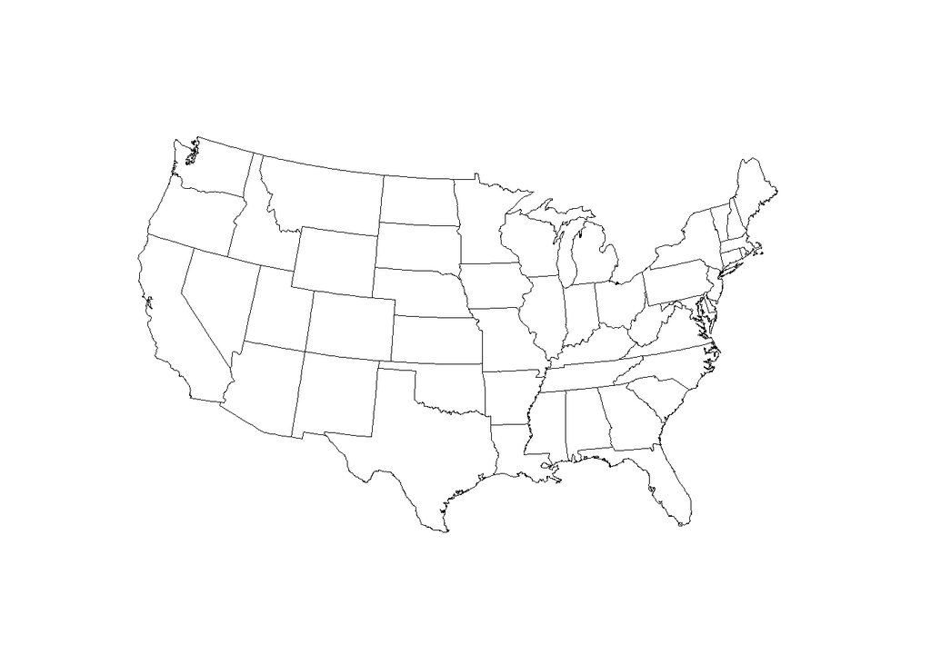

```r
library(maps)
library(ggthemes)

# make us map
us_map <- ggplot()+
  geom_polygon(data = states_map, aes(long, lat, group = group), color = "black", size = 0.1, fill = "white") +
  coord_map(projection = "albers", lat0 = 39, lat1 = 45) +
  theme_map()
us_map
```

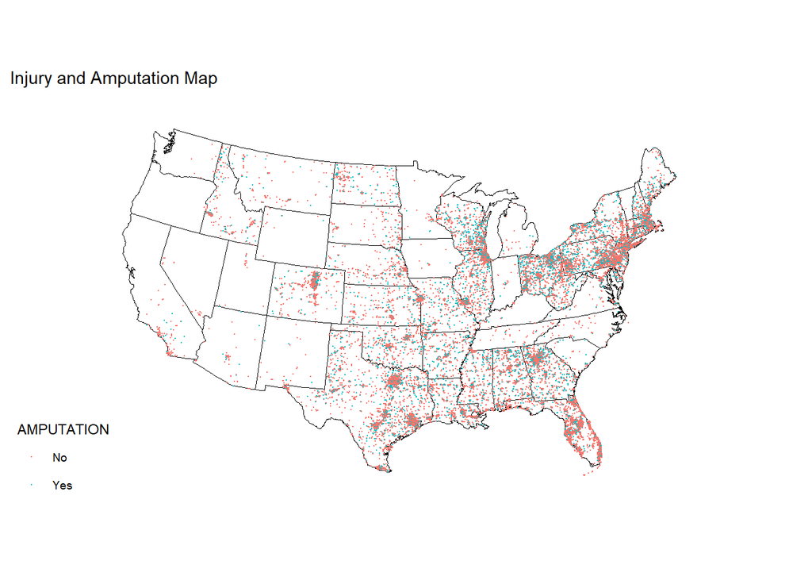

```r
# add injury data on us map
data_map <- data %>% mutate(LONGITUDE = as.numeric(LONGITUDE), LATITUDE =as.numeric(LATITUDE), AMPUTATION = as.factor(AMPUTATION)) %>% filter(LATITUDE > 20 & LATITUDE < 50 & LONGITUDE > -120) %>%
  mutate(AMPUTATION = if_else(AMPUTATION == 1, true = "Yes", false = "No"))

injury_map <- us_map + geom_point(data = data_map, aes(x=LONGITUDE, y=LATITUDE, color = AMPUTATION), size=0.0001) +
  ggtitle("Injury and Amputation Map")
injury_map
```

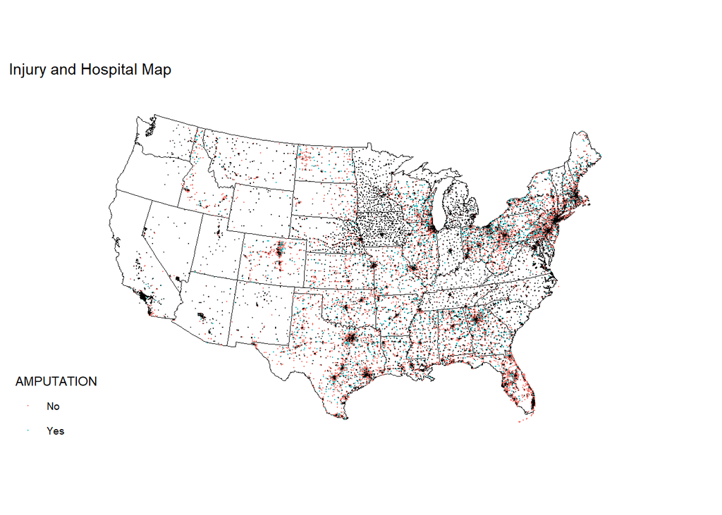

```r
# add hospital location on injury map
hosp_data <- read_csv("HPDATA.csv") %>% mutate(long= as.numeric(LONGI), lat= as.numeric(LATIT)) %>%
  filter(lat> 20 & lat< 50 & long > -120)
injury_map + geom_point(data = hosp_data, aes(x=long, y=lat), color = "black", size = 0.1, alpha = 0.5) +
  ggtitle("Injury and Hospital Map")
```

In these maps, red dots indicate “injury without amputaion”, blue dots indicate “injury with amputaion”. Black dots indicate hospitals. Amputation seems to be avoided around hospitals, and performed for cases getting injured far away from the hospital.

## bar graph

```r
data_bar <- data %>% mutate(AMPUTATION = as.factor(AMPUTATION)) %>%
                            group_by(AMPUTATION) %>%
  summarise(mean = mean(NEAR_DIST), sd =sd(NEAR_DIST), se = sd(NEAR_DIST)/sqrt(n())) %>%
  mutate(AMPUTATION = if_else(AMPUTATION == 1, true = "Yes", false = "No"))
data_bar
```

```
## # A tibble: 2 x 4
##   AMPUTATION  mean    sd    se
##   <chr>      <dbl> <dbl> <dbl>
## 1 No         5860. 7054.  39.0
## 2 Yes        6267. 6902.  63.2
```

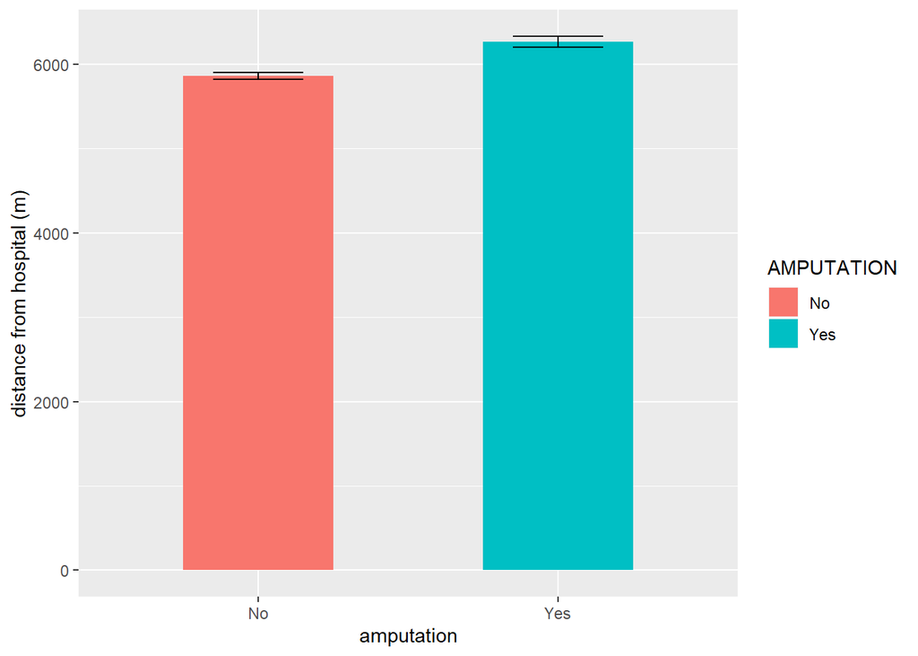

```r
data_bar %>%
  ggplot(aes(x = AMPUTATION, y = mean, fill=AMPUTATION)) +
  geom_bar(stat = "identity", width = 0.5)+
  geom_errorbar(aes(ymin=mean - se, ymax= mean +se), width = 0.3) +
  xlab("amputation")+
  ylab("distance from hospital (m)")
```

The bar graph shows distance from the injury place to the hospital is higher in patients with amputation than those without.

## boxplot

This graph compares the distance from hospital to the injury place between those who took amputation and those who didn’t. Please note the y axis is described in log 10 scale in meter.

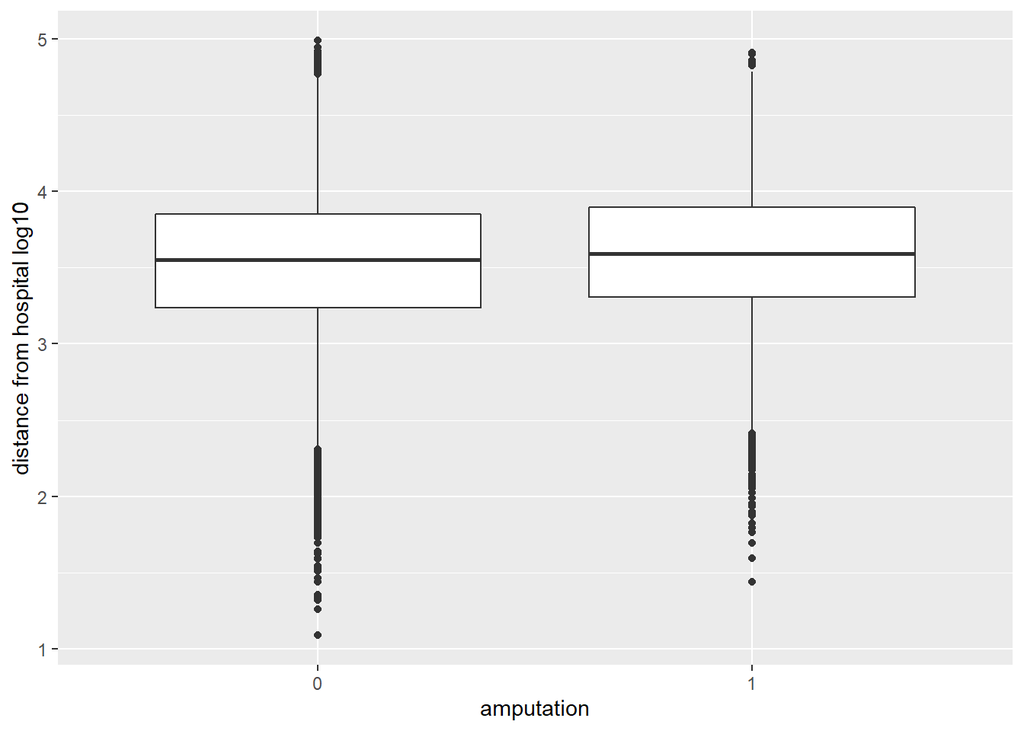

```r
data$HOSPITALIZED <- as.numeric(data$HOSPITALIZED)
data$MultiInj <- as.factor(data$MultiInj)
data$AMPUTATION <- as.factor(data$AMPUTATION)
data %>%
  ggplot(aes(x=AMPUTATION,y=log10(NEAR_DIST)))+
  geom_boxplot()+
  xlab("amputation")+
  ylab("distance from hospital log10")
```

The median distance of those who took amputation seems longer.

## density graph

This graph also comparing the distance from hospital between those who took amputation and not. The peak of data are in 1,000 to 10,000 meter.

blue: Amputation + red: amputation -

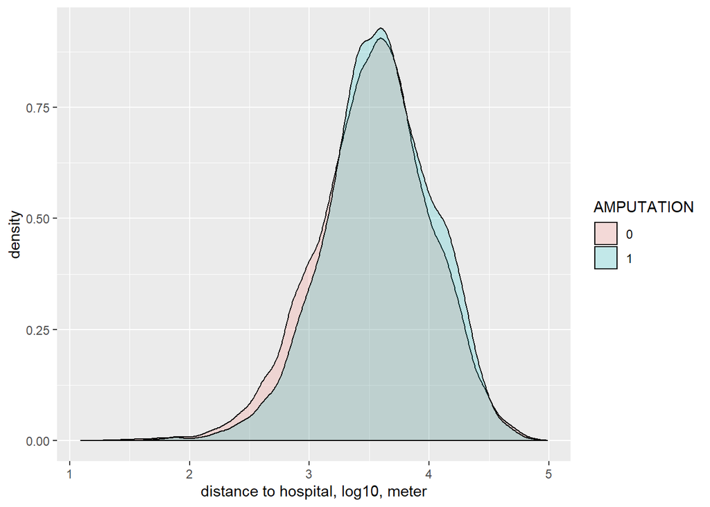

```r
data %>% ggplot(aes(log10(NEAR_DIST), fill=AMPUTATION)) + geom_density(alpha = 0.2)+
  xlab("distance to hospital, log10, meter")
```

## ttest Then, we performed stutent t test. There is a significant difference in distance from hospital(p<0.001).

```r
t.test(data$NEAR_DIST~data$AMPUTATION)
```

```
##
##  Welch Two Sample t-test
##
## data:  data$NEAR_DIST by data$AMPUTATION
## t = -5.4889, df = 21549, p-value = 4.091e-08
## alternative hypothesis: true difference in means is not equal to 0
## 95 percent confidence interval:
##  -553.3651 -262.1460
## sample estimates:
## mean in group 0 mean in group 1
##        5859.654        6267.409
```

Mean distance: Amp- 5860(m) Amp+ 6267 (m)

## regression

### univariate Regression (distance)

First, we saw the crude relationship between distance from hospital and probability of amputation.

```r
mlog <- glm(AMPUTATION ~ NEAR_DIST , data = data, family = "binomial")
summary(mlog)
```

```
##
## Call:
## glm(formula = AMPUTATION ~ NEAR_DIST, family = "binomial", data = data)
##
## Deviance Residuals:
##     Min       1Q   Median       3Q      Max
## -1.0587  -0.7858  -0.7772   1.5823   1.6475
##
## Coefficients:
##               Estimate Std. Error z value Pr(>|z|)
## (Intercept) -1.060e+00  1.401e-02  -75.64  < 2e-16 ***
## NEAR_DIST    7.975e-06  1.471e-06    5.42 5.97e-08 ***
## ---
## Signif. codes:  0 '***' 0.001 '**' 0.01 '*' 0.05 '.' 0.1 ' ' 1
##
## (Dispersion parameter for binomial family taken to be 1)
##
##     Null deviance: 51801  on 44659  degrees of freedom
## Residual deviance: 51773  on 44658  degrees of freedom
## AIC: 51777
##
## Number of Fisher Scoring iterations: 4
```

The distance from hospital is significantly increases the probability of amputation(p<0.001). #### Odds Ratio Then, odds ratio and 95% confidence interval was calculated.

```r
exp(cbind(OR = coef(mlog), confint(mlog)))
```

```
##                    OR     2.5 %    97.5 %
## (Intercept) 0.3465533 0.3371557 0.3561901
## NEAR_DIST   1.0000080 1.0000051 1.0000108
```

#### probability graph for univariate logistic regression

Next, we draw the graph showing the probability of amputation by distance from hospital. The gray band showes 95% CI.

```r
#create values
fit_1 <- with(data, data.frame(NEAR_DIST = rep(seq(from = 1, to = 100000, length.out = 1000), 2)))
#generate
fit_2 <- cbind(fit_1, predict(mlog, newdata = fit_1, type = "link",se = TRUE))
fit_2 <- within(fit_2, {
    PredictedProb <- plogis(fit)
    LL <- plogis(fit - (1.96 * se.fit))
    UL <- plogis(fit + (1.96 * se.fit))
})
## view first few rows of final dataset
head(fit_2)
```

```
##   NEAR_DIST       fit     se.fit residual.scale        UL        LL
## 1    1.0000 -1.059711 0.01400918              1 0.2626476 0.2521518
## 2  101.0991 -1.058912 0.01391461              1 0.2627663 0.2523373
## 3  201.1982 -1.058114 0.01382096              1 0.2628854 0.2525226
## 4  301.2973 -1.057316 0.01372825              1 0.2630049 0.2527077
## 5  401.3964 -1.056517 0.01363650              1 0.2631248 0.2528924
## 6  501.4955 -1.055719 0.01354573              1 0.2632451 0.2530769
##   PredictedProb
## 1     0.2573648
## 2     0.2575174
## 3     0.2576700
## 4     0.2578227
## 5     0.2579755
## 6     0.2581284
```

```r
nrow(fit_2)
```

```
## [1] 2000
```

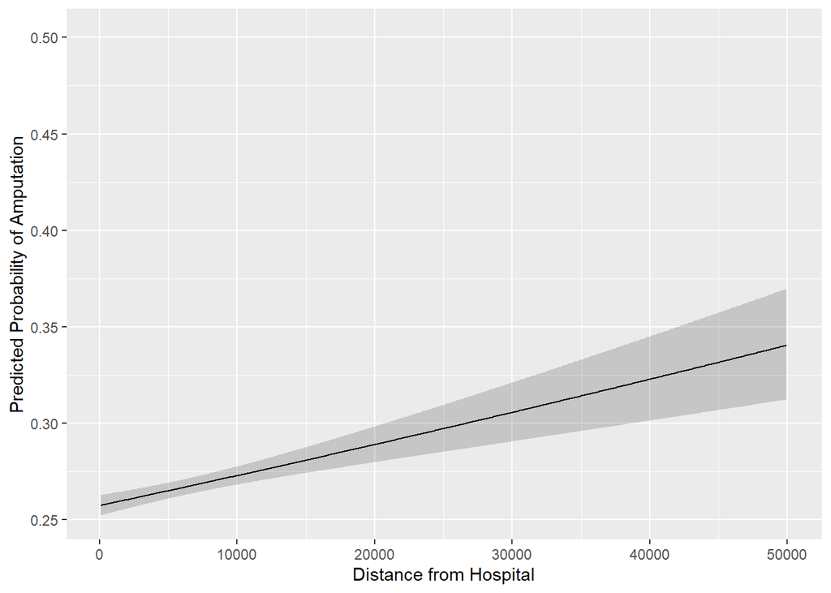

```r
#plot
ggplot(fit_2, aes(x = NEAR_DIST, y = PredictedProb)) + geom_ribbon(aes(ymin = LL,
    ymax = UL), alpha = 0.2) + geom_line()+xlab("Distance from Hospital")+ylab("Predicted Probability of Amputation")+xlim(100,50000)
```

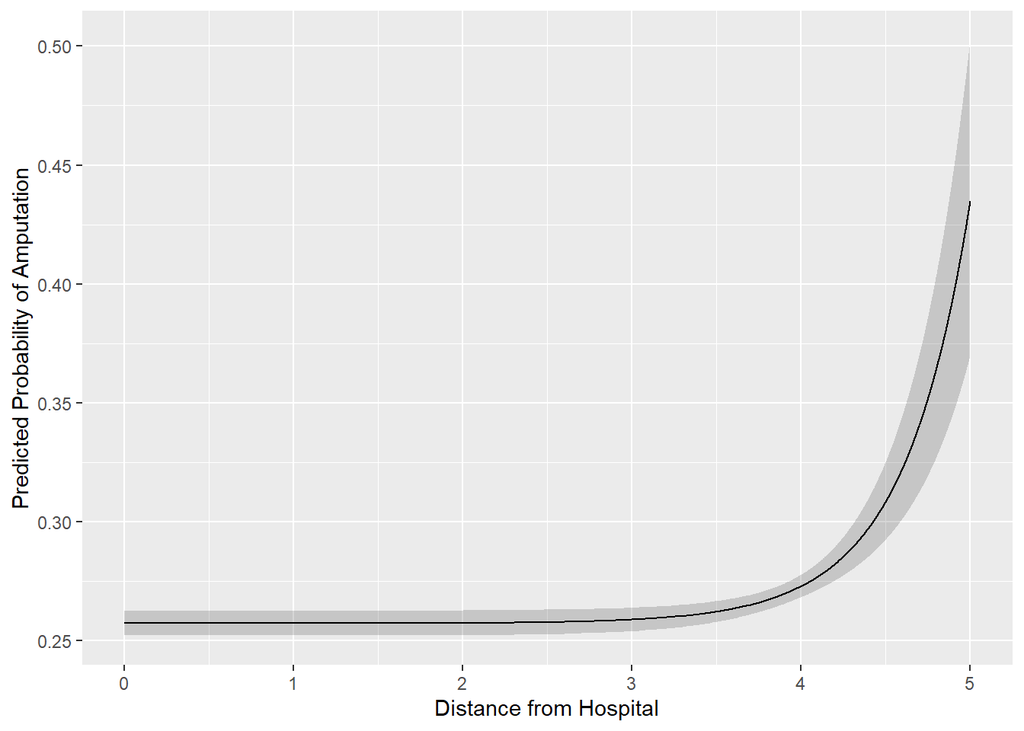

```r
ggplot(fit_2, aes(x = log10(NEAR_DIST), y = PredictedProb)) + geom_ribbon(aes(ymin = LL,
    ymax = UL), alpha = 0.2) + geom_line()+xlab("Distance from Hospital")+ylab("Predicted Probability of Amputation")
```

### multivariate logistic Regression (distance, hospitalization, multiple injury+/-) We also performed multivariable logistic regression analysis. Hostipalization and multiple injury (binomial) were adjusted.

```r
mylogit <- glm(AMPUTATION ~ NEAR_DIST  + HOSPITALIZED + MultiInj, data = data, family = "binomial")
summary(mylogit)
```

```
##
## Call:
## glm(formula = AMPUTATION ~ NEAR_DIST + HOSPITALIZED + MultiInj,
##     family = "binomial", data = data)
##
## Deviance Residuals:
##     Min       1Q   Median       3Q      Max
## -3.3385  -0.4497  -0.4443   0.1020   3.4193
##
## Coefficients:
##                Estimate Std. Error z value Pr(>|z|)
## (Intercept)   5.126e+00  1.417e-01  36.172  < 2e-16 ***
## NEAR_DIST     8.070e-06  2.477e-06   3.258  0.00112 **
## HOSPITALIZED -7.405e+00  1.421e-01 -52.096  < 2e-16 ***
## MultiInj1    -3.570e+00  2.927e-01 -12.195  < 2e-16 ***
## ---
## Signif. codes:  0 '***' 0.001 '**' 0.01 '*' 0.05 '.' 0.1 ' ' 1
##
## (Dispersion parameter for binomial family taken to be 1)
##
##     Null deviance: 51801  on 44659  degrees of freedom
## Residual deviance: 21378  on 44656  degrees of freedom
## AIC: 21386
##
## Number of Fisher Scoring iterations: 8
```

Distance from hospital still increase the OR of amputation adjusting these 2 confounders.

#### Odds Ratio

```r
exp(cbind(OR = coef(mylogit), confint(mylogit)))
```

```
##                        OR        2.5 %       97.5 %
## (Intercept)  1.683448e+02 1.290296e+02 2.251316e+02
## NEAR_DIST    1.000008e+00 1.000003e+00 1.000013e+00
## HOSPITALIZED 6.080158e-04 4.543011e-04 7.940252e-04
## MultiInj1    2.815471e-02 1.514230e-02 4.787999e-02
```

Estimated Odds Ratio for 1 m increase in distance is 1.000008 (95% CI: 1.000003-1.000013).

As a result, 1 km increase in distance from hospital raise 1.008 times Odds of amputation, adjusting hospitalization and multiple injury.

## conclusion

• In this study, the longer distance from injury site to a hospital was significantly associated with amputation in trauma patients.

• The US, the country having vast land, have to care about the disposition of hospitals.